# R: Vector Manipulation

Peter Freeman (2019 SLSW)

24 June 2019

# Motivation

A *vector* in `R` is a homogeneous collection of numbers, strings, or `TRUE`/`FALSE` values (i.e., logicals).

A collection of (column) vectors, all of the same length, can be bound together into a data table (called a *data frame*) that might provide the input to, e.g., a regression analysis. So in our discussion of statistical learning, it makes sense to start with a discussion of `R` vectors and how you might use (and manipulate!) them.

# Vectors in R

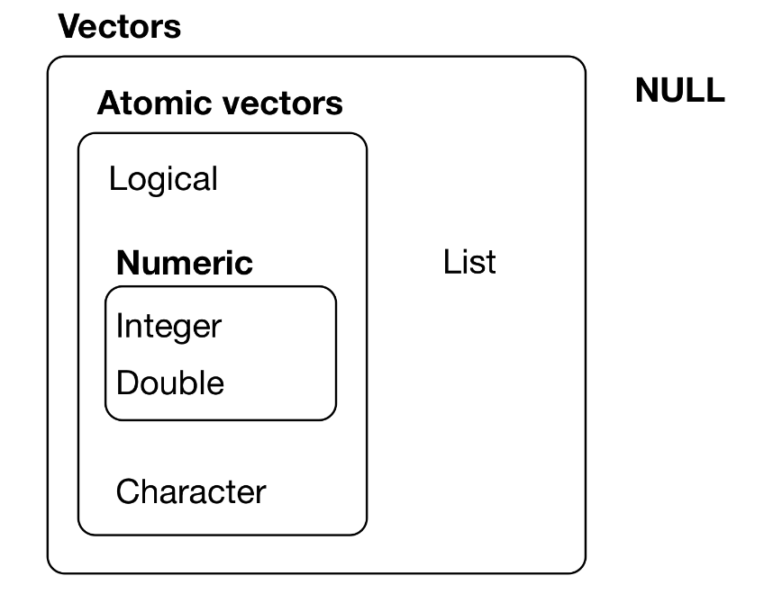

Atomic vectors are *homogeneous*, i.e., all elements of the vectors are of the same type. The types of atomic vectors (or just vectors) are:

- `double`: double-precision floating-point numbers (8 bytes per element);
- `integer`: integer numbers (4 bytes per element);
- `logical`: `TRUE` and `FALSE`;
- `character`: individual strings (at 1 byte per individual character within each string);
- and `complex` and `raw` (not covered here).

Note: the `integer` and `double` types are collectively (and at times confusingly) dubbed `numeric`. (Confusingly because one can cast to a numeric type, which is equivalent to casting to double.)

# Initializing Vectors

Let’s show the various ways in which one can initialize a vector (in this case, of integers) of length five:

| `x = c(0,0,0,0,0)` | c = “collection” or “container” |
| --- | --- |
| `x = rep(0,5)` | rep = “repeat” |
| `x = vector(“integer”,5)` |  |
| `x = integer(5)` |  |
| `x = seq(1,5,by=1)` | seq = “sequence” |
| `x = 1:5` | steps by 1 |

Note that one can use all six of these functions to initialize `numeric` vectors, and the first four to initialize those of mode `logical` or `character`, as with, e.g.,

```r
vector("logical",5)
```

```
## [1] FALSE FALSE FALSE FALSE FALSE
```

```r
character(5)
```

```
## [1] "" "" "" "" ""
```

# Handy Vector Functions

To determine the type of a vector:

```r
x = c(1,0,3,2)
typeof(x)
```

```
## [1] "double"
```

To determine the number of elements in a vector:

```r
length(x)
```

```
## [1] 4
```

To display the $n^{th}$ element of a vector, where $n \in [1,length(x)]$:

```r
x[1]
```

```
## [1] 1
```

To explicitly cast from one type to another:

```r
as.character(x)
```

```
## [1] "1" "0" "3" "2"
```

# Handy Vector Functions

To sort a vector in ascending order, and to retrieve the sorted vector indices:

```r
x
```

```
## [1] 1 0 3 2
```

```r
sort(x)
```

```
## [1] 0 1 2 3
```

```r
order(x)
```

```
## [1] 2 1 4 3
```

To display the unique values of a vector:

```r
unique(x)
```

```
## [1] 1 0 3 2
```

```r
table(x)
```

```
## x
## 0 1 2 3
## 1 1 1 1
```

# Logical Subsetting

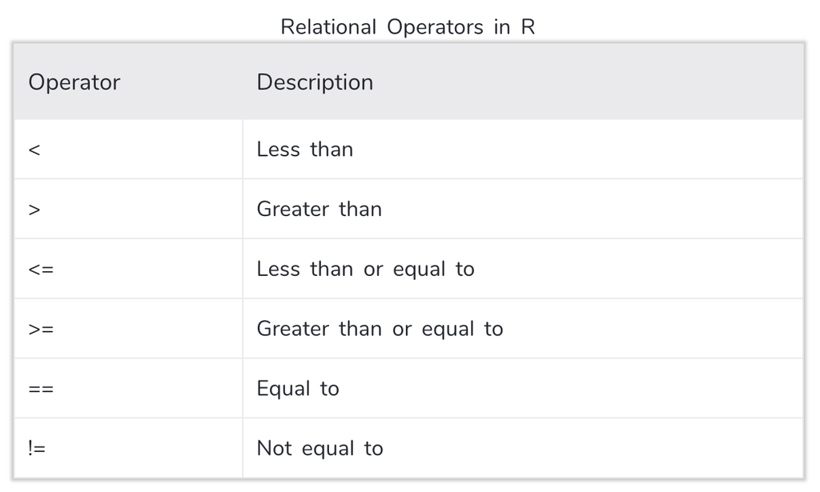

If you apply a relational operator to a vector, the output will be a logical vector:

```r
set.seed(101)
x = rnorm(10)
x>0
```

```
##  [1] FALSE  TRUE FALSE  TRUE  TRUE  TRUE  TRUE FALSE  TRUE FALSE
```

# Logical Subsetting

**¡MUY IMPORTANTE!** If you apply a logical vector of length $n$ to a vector of length $n$, then *only the elements of the second vector associated with the value TRUE will be displayed!* For instance:

```r
x
```

```
##  [1] -0.3260365  0.5524619 -0.6749438  0.2143595  0.3107692  1.1739663
##  [7]  0.6187899 -0.1127343  0.9170283 -0.2232594
```

```r
x[x>0]
```

```
## [1] 0.5524619 0.2143595 0.3107692 1.1739663 0.6187899 0.9170283
```

# Logical Subsetting

The output from relational operators can be combined using the logical and operator (&) or the logical or operator (|):

```r
y = x>0 & x<0.5
x[y]
```

```
## [1] 0.2143595 0.3107692
```

```r
y = x<0 | x>0.5
x[y]
```

```
## [1] -0.3260365  0.5524619 -0.6749438  1.1739663  0.6187899 -0.1127343
## [7]  0.9170283 -0.2232594
```

# Logical Subsetting: sum()

To determine how many values in your vector satisfy a condition, combine one or more relational operators with the `sum()` function:

```r
sum(x>-0.5&x<0)
```

```
## [1] 3
```

# Logical Subsetting: which()

To determine which elements of the original vector satisfy a condition, combine one or more relational operators with the `which()` function:

```r
which(x>-0.5&x<0)
```

```
## [1]  1  8 10
```

Another means by which to subset a vector is to apply the output of the `which()` function. Note how adding a minus sign changes the output!

```r
w = which(x<0)
x[w]
```

```
## [1] -0.3260365 -0.6749438 -0.1127343 -0.2232594
```

```r
x[-w]
```

```
## [1] 0.5524619 0.2143595 0.3107692 1.1739663 0.6187899 0.9170283
```

# Missing Data: NA

`NA` means “Not Available” and is the preferred way in `R` to denote missing data.

To determine whether vector elements are `NA`, we can use the `is.na()` function, which returns a logical vector.

```r
x = c(1,NA,3)
is.na(x)
```

```
## [1] FALSE  TRUE FALSE
```